# mlassign1

```python
import pandas as pd
import numpy as np
import matplotlib.pyplot as plt
from sklearn.model_selection import train_test_split
```

```python
df = pd.read_csv('bottle.csv')
```

```python
df.head()
```

|  | Cst_Cnt | Btl_Cnt | Sta_ID | Depth_ID | Depthm | T_degC | Salnty | O2ml_L | STheta | O2Sat | ... | R_PHAEO | R_PRES | R_SAMP | DIC1 | DIC2 | TA1 | TA2 | pH2 | pH1 | DIC Quality Comment |
| --- | --- | --- | --- | --- | --- | --- | --- | --- | --- | --- | --- | --- | --- | --- | --- | --- | --- | --- | --- | --- | --- |
| 0 | 1 | 1 | 054.0 056.0 | 19-4903CR-HY-060-0930-05400560-0000A-3 | 0 | 10.50 | 33.440 | NaN | 25.649 | NaN | ... | NaN | 0 | NaN | NaN | NaN | NaN | NaN | NaN | NaN | NaN |
| 1 | 1 | 2 | 054.0 056.0 | 19-4903CR-HY-060-0930-05400560-0008A-3 | 8 | 10.46 | 33.440 | NaN | 25.656 | NaN | ... | NaN | 8 | NaN | NaN | NaN | NaN | NaN | NaN | NaN | NaN |
| 2 | 1 | 3 | 054.0 056.0 | 19-4903CR-HY-060-0930-05400560-0010A-7 | 10 | 10.46 | 33.437 | NaN | 25.654 | NaN | ... | NaN | 10 | NaN | NaN | NaN | NaN | NaN | NaN | NaN | NaN |
| 3 | 1 | 4 | 054.0 056.0 | 19-4903CR-HY-060-0930-05400560-0019A-3 | 19 | 10.45 | 33.420 | NaN | 25.643 | NaN | ... | NaN | 19 | NaN | NaN | NaN | NaN | NaN | NaN | NaN | NaN |
| 4 | 1 | 5 | 054.0 056.0 | 19-4903CR-HY-060-0930-05400560-0020A-7 | 20 | 10.45 | 33.421 | NaN | 25.643 | NaN | ... | NaN | 20 | NaN | NaN | NaN | NaN | NaN | NaN | NaN | NaN |

5 rows × 74 columns

```python
df.shape
```

```
(864863, 74)
```

```python
df = df[['T_degC', 'Salnty', 'STheta']]
```

```python
df.shape
```

```
(864863, 3)
```

```python
df = df.dropna()
```

```python
df.shape
```

```
(812174, 3)
```

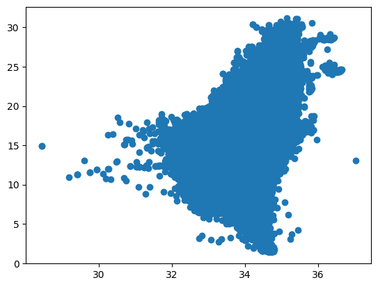

```python
plt.scatter(df['Salnty'],df['T_degC'])
```

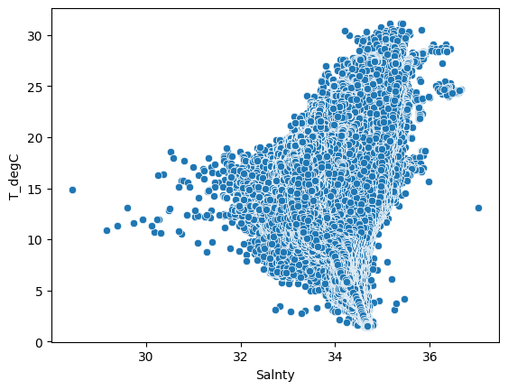

```python
import seaborn as sns
sns.scatterplot(x='Salnty',y='T_degC',data=df)
```

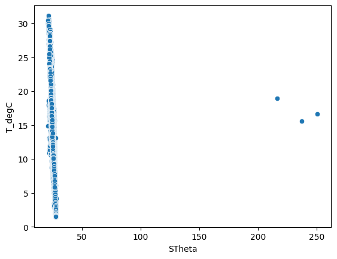

```python
sns.scatterplot(x='STheta',y='T_degC',data=df)
```

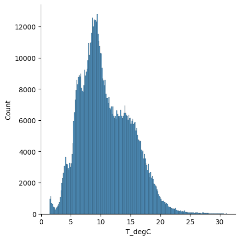

```python
sns.displot(x='T_degC',data=df)
```

```python
((df['STheta']>100)==True).sum()
```

```
6
```

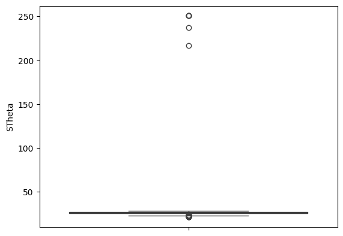

```python
sns.boxplot(y='STheta',data = df)
```

```python
df = df[df['STheta']<100]
```

```python
df.shape
```

```
(812168, 3)
```

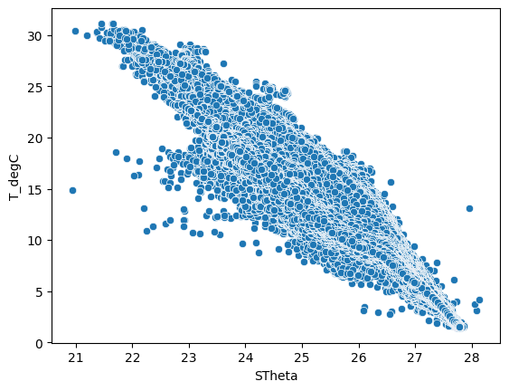

```python
sns.scatterplot(x='STheta',y='T_degC',data=df)
```

```python
X= df.drop('T_degC',axis=1)
y=df['T_degC']
X_train, X_test, y_train, y_test = train_test_split( X, y, test_size=0.2, random_state=42)
```

```python
df.shape[0]
```

```
812168
```

```python
X_tnew = np.c_[np.ones((X_train.shape[0], 1)), X_train]
X_testnew = np.c_[np.ones((X_test.shape[0], 1)), X_test]
```

```python
X_tnew.shape
```

```
(649734, 3)
```

```python
X_testnew[:5]
```

```
array([[ 1.   , 34.309, 26.694],
       [ 1.   , 34.149, 26.741],
       [ 1.   , 34.514, 27.348],
       [ 1.   , 34.164, 26.931],
       [ 1.   , 34.344, 26.786]])
```

```python
theta_best = np.linalg.inv(X_tnew.T.dot(X_tnew)).dot(X_tnew.T).dot(y_train)
```

```python
theta_best
```

```
array([35.64451188,  3.11151204, -5.03907257])
```

```python
y_pred = X_testnew.dot(theta_best)
```

```python
y_pred
```

```
array([ 7.88437556,  7.14969722,  5.22668207, ...,  7.14752462,
       16.11974133, 15.64019849])
```

[output not shown]

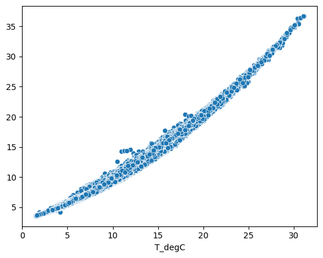

```python
sns.scatterplot(x= y_test, y=y_pred)
#plt.plot(X, y, "b.")
#plt.axis([0, 2, 0, 15])
plt.show()
```

```python
from sklearn.metrics import mean_squared_error
from sklearn.metrics import r2_score
from sklearn.metrics import explained_variance_score
mean_squared_error(y_test,y_pred)
```

```
0.23378301431778972
```

```python
mean_squared_error(y_test,y_pred)
r2_score(y_test,y_pred)
```

```
0.9868919565634456
```

```python
explained_variance_score(y_test,y_pred)
```

```
0.9868919614560959
```

```python
from sklearn.linear_model import LinearRegression
model = LinearRegression()
model.fit(X_train,y_train)
```

```
LinearRegression()
```

```python
model.coef_
```

```
array([ 3.11151204, -5.03907257])
```

```python
model.intercept_
```

```
35.64451187804467
```

```python
y_pred_sklearn = model.predict(X_test)
```

```python
mean_squared_error(y_test,y_pred_sklearn)
```

```
0.2337830143181198
```

```python
explained_variance_score(y_test,y_pred_sklearn)
```

```
0.9868919614560767
```

```python
r2_score(y_test,y_pred_sklearn)
```

```
0.9868919565634271
```

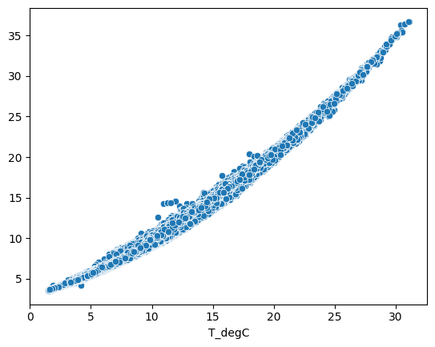

```python
sns.scatterplot(x= y_test, y=y_pred_sklearn)
```

The evaluation metrics for both the methods are the same indicating similar performance

##### 1) Why is it important to have a test set?

A test set is provided during each model evaluation to understand how the data would perform when given unseen data. The whole idea is to see if the model is performing well on data that it has not previously encountered as that would help us know how good the model is. We would also have the labels as the test set is from our own data to compare and further better the model.

##### 2) If the normal equation always provides a solution, when would we not want to use it?

The process to calculate (X’X) and then its invert form is expensive and costs O(N³) where N is the number of rows/observations in X matrix. (X’X) might be non-invertible, a violation of our assumption. In such cases, linearly-dependent redundant features might be removed, or regularization methods like lasso be used to lessen the number of features.

##### 4) Explain what bias is and what variance is in regards to the bias-variance tradeoff.

Bias is the training error. It is how the model performs after being trained with some data and the residual error between the predicted values and actual values of training set. Variance is the error that a model on the test set. If the model performs too well on the train set but poorly on the test set it means it is overfitting the training set and thus we need to apply regularization methods to reduce this test error. If it is performing poorly on training and test set, the data is underfitting and we need to increase the complexity of the model.

Error is the sum of Bias², variance and the irreducible error. We need to find the sweet spot between the bias and variance where both of them are low and do not underfit/overfit

##### 5) In a linear regression model, how might we reduce bias?

To reduce bias, increasing model complexity by tuning the hyperparameters can help. We can also form new features by transformations/ feature engineering to fit the model better. Complexity can be increased by using polynomial features, interaction terms, or adding more variables to the model.

##### 6) In a linear regression model, how might we reduce variance?

To reduce variance, decreasing the complexity of the model by removing irrelevant features or applying regularization can aid in doing so. Using techniques like k-fold cross-validation can provide estimates of the model's performance on unseen data, helping to identify and mitigate overfitting.